# Summer Juvenile Fish

Kevin See[^1]

December 04, 2019

# Introduction

We used quantile random forests (Meinshausen (2006)) for this investigation because random forests allow for non-linear fish-habitat relationships, naturally incorporate any correlation or interactions between habitat covariates, and allow us to examine a predicted quantile (Cade and Noon (2003)), rather than only the mean of the predicted response.

# Data

Many sites were sampled in multiple years. To avoid any chance of pseudo-replication (since habitat data is not usually expected to vary much year-to-year), for any site with multiple surveys, we chose the survey with the highest estimated density. We used this criteria because we are interested in estimating carrying capacity, so using the highest observed density seemed appropriate.

*All sites fell within the range of steelhead, but many of them were outside the range of spring/summer Chinook salmon. However, defining the range of sp/su Chinook is tricky, and it is unclear if the reported data for Chinook salmon includes only sites considered with the range of Chinook, or if we should exclude data from some sites based on our best understanding of the species’ range. Currently, we are excluding sites outside the Chinook domain. We created our own list of sites in the John Day that were within a Chinook domain, based on which sites Chinook were found at some point (and downstream of those).*

```
#> Coordinate Reference System:
#>   EPSG: 5070
#>   proj4string: "+proj=aea +lat_1=29.5 +lat_2=45.5 +lat_0=23 +lon_0=-96 +x_0=0 +y_0=0 +ellps=GRS80 +towgs84=0,0,0,0,0,0,0 +units=m +no_defs"
```

After matching up the fish abundances with sites where we have habitat data, we are left with the following number of sites.

|  |  | Year | 2011 | 2012 | 2013 | 2014 | 2015 | 2016 | 2017 | Sum |
| --- | --- | --- | --- | --- | --- | --- | --- | --- | --- | --- |
| Watershed | Species |  |  |  |  |  |  |  |  |  |
| Asotin | Chinook |  | 0 | 0 | 0 | 0 | 0 | 0 | 0 | 0 |
|  | Steelhead |  | 4 | 1 | 2 | 2 | 3 | 1 | 1 | 14 |
| Entiat | Chinook |  | 17 | 10 | 7 | 3 | 13 | 10 | 1 | 61 |
|  | Steelhead |  | 10 | 11 | 8 | 15 | 19 | 22 | 0 | 85 |
| John Day | Chinook |  | 9 | 18 | 8 | 5 | 8 | 6 | 6 | 60 |
|  | Steelhead |  | 40 | 46 | 19 | 23 | 27 | 25 | 10 | 190 |
| Lemhi | Chinook |  | 13 | 6 | 0 | 1 | 6 | 8 | 0 | 34 |
|  | Steelhead |  | 19 | 19 | 2 | 12 | 12 | 14 | 5 | 83 |
| Minam | Chinook |  | 0 | 0 | 5 | 5 | 10 | 0 | 0 | 20 |
|  | Steelhead |  | 0 | 0 | 5 | 6 | 9 | 0 | 0 | 20 |
| South Fork Salmon | Chinook |  | 18 | 12 | 0 | 0 | 0 | 0 | 0 | 30 |
|  | Steelhead |  | 15 | 18 | 0 | 0 | 0 | 0 | 0 | 33 |
| Upper Grande Ronde | Chinook |  | 25 | 12 | 15 | 2 | 15 | 9 | 8 | 86 |
|  | Steelhead |  | 9 | 15 | 14 | 34 | 20 | 27 | 11 | 130 |
| Wenatchee | Chinook |  | 8 | 7 | 7 | 0 | 0 | 0 | 0 | 22 |
|  | Steelhead |  | 13 | 14 | 15 | 0 | 0 | 0 | 0 | 42 |
| Sum | Chinook |  | 90 | 65 | 42 | 16 | 52 | 33 | 15 | 313 |
|  | Steelhead |  | 110 | 124 | 65 | 92 | 90 | 89 | 27 | 597 |

|  | Year |  |  |  |  |  |  |  |
| --- | --- | --- | --- | --- | --- | --- | --- | --- |
| Watershed | 2011 | 2012 | 2013 | 2014 | 2015 | 2016 | 2017 | Total |
| Asotin | 0% (0) | 0% (0) | 0% (0) | 0% (0) | 0% (0) | 0% (0) | 0% (0) | 0% (0) |
| Entiat | 19% (17) | 15% (10) | 17% (7) | 19% (3) | 25% (13) | 30% (10) | 7% (1) | 19% (61) |
| John Day | 10% (9) | 28% (18) | 19% (8) | 31% (5) | 15% (8) | 18% (6) | 40% (6) | 19% (60) |
| Lemhi | 14% (13) | 9% (6) | 0% (0) | 6% (1) | 12% (6) | 24% (8) | 0% (0) | 11% (34) |
| Minam | 0% (0) | 0% (0) | 12% (5) | 31% (5) | 19% (10) | 0% (0) | 0% (0) | 6% (20) |
| South Fork Salmon | 20% (18) | 18% (12) | 0% (0) | 0% (0) | 0% (0) | 0% (0) | 0% (0) | 10% (30) |
| Upper Grande Ronde | 28% (25) | 18% (12) | 36% (15) | 13% (2) | 29% (15) | 27% (9) | 53% (8) | 27% (86) |
| Wenatchee | 9% (8) | 11% (7) | 17% (7) | 0% (0) | 0% (0) | 0% (0) | 0% (0) | 7% (22) |
| Total | 100% (90) | 100% (65) | 100% (42) | 100% (16) | 100% (52) | 100% (33) | 100% (15) | 100% (313) |

|  | Year |  |  |  |  |  |  |  |
| --- | --- | --- | --- | --- | --- | --- | --- | --- |
| Watershed | 2011 | 2012 | 2013 | 2014 | 2015 | 2016 | 2017 | Total |
| Asotin | 4% (4) | 1% (1) | 3% (2) | 2% (2) | 3% (3) | 1% (1) | 4% (1) | 2% (14) |
| Entiat | 9% (10) | 9% (11) | 12% (8) | 16% (15) | 21% (19) | 25% (22) | 0% (0) | 14% (85) |
| John Day | 36% (40) | 37% (46) | 29% (19) | 25% (23) | 30% (27) | 28% (25) | 37% (10) | 32% (190) |
| Lemhi | 17% (19) | 15% (19) | 3% (2) | 13% (12) | 13% (12) | 16% (14) | 19% (5) | 14% (83) |
| Minam | 0% (0) | 0% (0) | 8% (5) | 7% (6) | 10% (9) | 0% (0) | 0% (0) | 3% (20) |
| South Fork Salmon | 14% (15) | 15% (18) | 0% (0) | 0% (0) | 0% (0) | 0% (0) | 0% (0) | 6% (33) |
| Upper Grande Ronde | 8% (9) | 12% (15) | 22% (14) | 37% (34) | 22% (20) | 30% (27) | 41% (11) | 22% (130) |
| Wenatchee | 12% (13) | 11% (14) | 23% (15) | 0% (0) | 0% (0) | 0% (0) | 0% (0) | 7% (42) |
| Total | 100% (110) | 100% (124) | 100% (65) | 100% (92) | 100% (90) | 100% (89) | 100% (27) | 100% (597) |

# Selecting Covariates

A key step in developing a QRF model to predict fish capacities is selecting the habitat covariates to include in the model. Random forest models naturally incorporate interactions between correlated covariates, which is essential since nearly all habitat variables are considered correlated to one degree or another. However, we aimed to avoid overly redundant variables (i.e., variables that measure similar aspects of the habitat). Further, including too many covariates can result in overfitting of the model (e.g., including as many covariates as data points).

## Methods

| x | y | r |
| --- | --- | --- |
| WetWdth_Int | Area_Wet | 0.9119384 |
| WetWdth_Int | Lgth_Wet | 0.7715728 |
| WetWdth_Int | Lgth_WetChnl | 0.7662683 |
| WetWdth_Int | MeanU | 0.8469039 |
| WetWdth_Int | Q | 0.8516994 |
| WetWdth_Int | FstTurb_Area | 0.7161296 |
| WetWdth_Int | CUMDRAINAG | 0.6828048 |
| WetWdth_Int | SlowWater_Area | 0.6756399 |
| WetWdth_Int | FstNT_Area | 0.5726297 |
| WetWdth_Int | FstTurb_Freq | -0.5833691 |
| WetWdth_Int | CU_Freq | -0.6352683 |
| Area_Wet | Lgth_Wet | 0.8667596 |
| Area_Wet | Lgth_WetChnl | 0.8507934 |
| Area_Wet | MeanU | 0.8351186 |
| Area_Wet | Q | 0.8249517 |
| Area_Wet | FstTurb_Area | 0.7357678 |
| Area_Wet | CUMDRAINAG | 0.7191960 |
| Area_Wet | SlowWater_Area | 0.7849524 |
| Area_Wet | FstNT_Area | 0.6462413 |
| Area_Wet | FstTurb_Freq | -0.5097484 |
| Area_Wet | CU_Freq | -0.5543907 |
| Lgth_Wet | Lgth_WetChnl | 0.9649316 |
| Lgth_Wet | MeanU | 0.6426281 |
| Lgth_Wet | Q | 0.6146664 |
| Lgth_Wet | FstTurb_Area | 0.6763547 |
| Lgth_Wet | CUMDRAINAG | 0.5631088 |
| Lgth_Wet | SlowWater_Area | 0.6374164 |
| Lgth_Wet | FstNT_Area | 0.5739044 |
| Lgth_Wet | FstTurb_Freq | -0.5840197 |
| Lgth_Wet | CU_Freq | -0.6254905 |
| Lgth_WetChnl | MeanU | 0.6159286 |
| Lgth_WetChnl | Q | 0.5995797 |
| Lgth_WetChnl | FstTurb_Area | 0.6639467 |
| Lgth_WetChnl | CUMDRAINAG | 0.5481423 |
| Lgth_WetChnl | SlowWater_Area | 0.6129134 |
| Lgth_WetChnl | FstNT_Area | 0.5632336 |
| Lgth_WetChnl | FstTurb_Freq | -0.5445635 |
| Lgth_WetChnl | CU_Freq | -0.5826889 |
| MeanU | Q | 0.8153566 |
| MeanU | FstTurb_Area | 0.5570748 |
| MeanU | CUMDRAINAG | 0.8356153 |
| MeanU | SlowWater_Area | 0.7020739 |
| MeanU | FstNT_Area | 0.5997164 |
| Q | FstTurb_Area | 0.6339580 |
| Q | CUMDRAINAG | 0.7045645 |
| Q | SlowWater_Area | 0.6495892 |
| Q | CU_Freq | -0.5181071 |
| FstTurb_Area | SubD50 | 0.6161682 |
| FstTurb_Area | SubEstBldr | 0.5081981 |
| FstTurb_Area | CU_Freq | -0.5133054 |
| CUMDRAINAG | SlowWater_Area | 0.6388578 |
| FishCovNone | FishCovLW | -0.5105477 |
| FishCovNone | FishCovTVeg | -0.7019845 |
| FishCovNone | FishCovTotal | -0.9398004 |
| SubD50 | SubD16 | 0.6515825 |
| SubD50 | SubEstBldr | 0.7754058 |
| SubD50 | SubEstSandFines | -0.5069525 |
| SubD16 | SubEstSandFines | -0.5020324 |
| DistPrin1 | NatPrin2 | -0.5646923 |
| SubEstBldr | SubEstGrvl | -0.5871095 |
| LWVol_Wet | LWVol_WetSlow | 0.9049205 |
| LWVol_Wet | LWVol_WetFstNT | 0.7088553 |
| WetSCL_Area | WetBraid | 0.5077646 |
| WetSCL_Area | WetSC_Pct | 0.5672204 |
| LWVol_WetSlow | LWVol_WetFstNT | 0.6221684 |
| avg_aug_temp | NatPrin2 | -0.6812181 |
| WetBraid | WetSC_Pct | 0.7624962 |
| WetBraid | Wet_QIsland_Ct | 0.7733291 |
| WetSC_Pct | Wet_QIsland_Ct | 0.5996371 |
| LWFreq_Wet | FishCovLW | 0.5807728 |
| FishCovLW | FishCovTotal | 0.5634518 |
| FishCovTVeg | FishCovTotal | 0.7342052 |
| FstTurb_Freq | CU_Freq | 0.8442571 |

## Results

The MINE results are shown in the plots below.

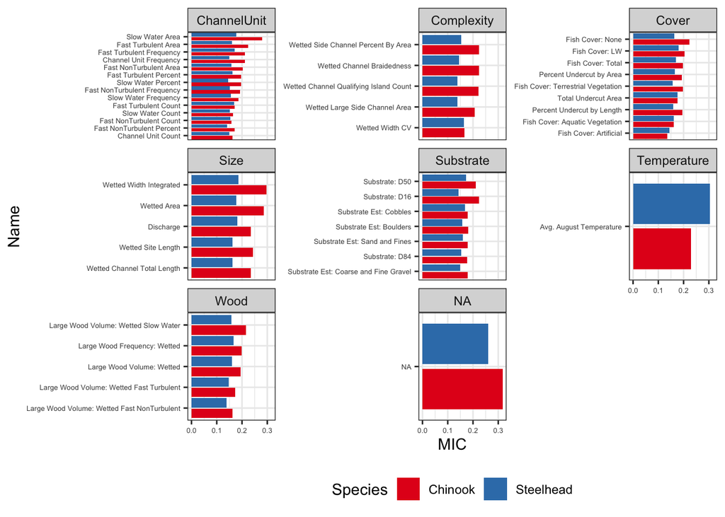

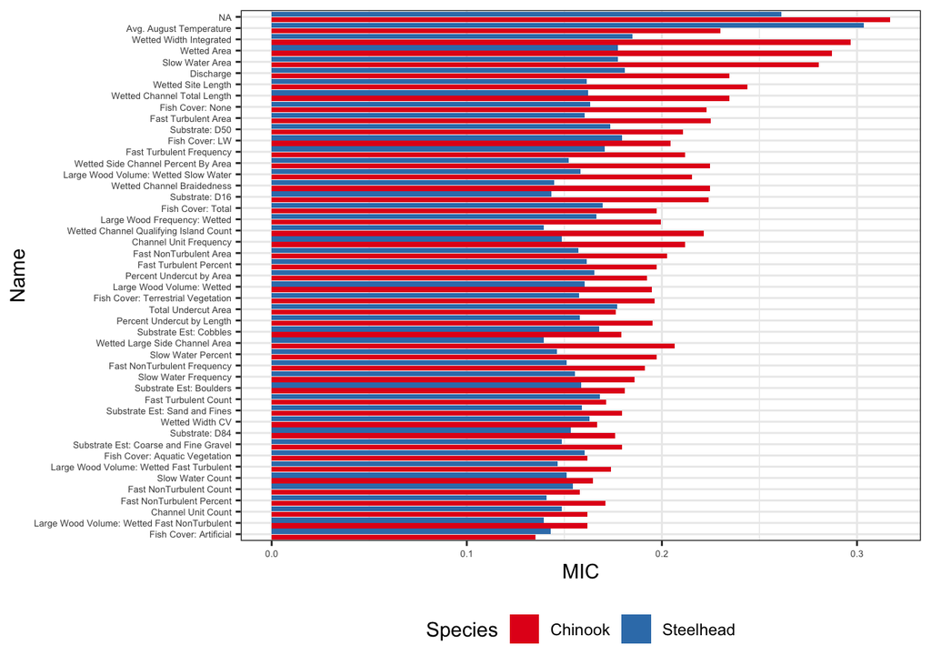

In the end, we decided to use the same metrics for both species, and chose the following metrics:

| Catg | Metric | Description |
| --- | --- | --- |
| Temperature | Avg. August Temperature | Average predicted daily August temperature from NorWest, averaged across the years 2002-2011. |
| ChannelUnit | Channel Unit Frequency | Number of channel units per 100 meters. |
| Land Classification | Disturbance Class PCA 1 | Disturbance Classification PCA 1 Score |
| Cover | Fish Cover: None | Percent of channel unit with no fish cover. |
| Cover | Fish Cover: None | Percent of channel unit with no fish cover. |
| ChannelUnit | Fast NonTurbulent Frequency | Number of Fast Water Non-Turbulent channel units per 100 meters. |
| ChannelUnit | Fast Turbulent Frequency | Number of Fast Water Turbulent channel units per 100 meters. |
| Wood | Large Wood Frequency: Wetted | Number of large wood pieces per 100 meters within the wetted channel. |
| Wood | Large Wood Volume: Wetted Fast Turbulent | Total volume of large wood pieces within the wetted channel and Fast Water Turbulent channel units. |
| Land Classification | Natural Class PCA 1 | Natural Classification PCA 1 Score |
| Size | Discharge | The sum of station discharge across all stations. Station discharge is calculated as depth x velocity x station increment for all stations except first and last. Station discharge for first and last s… |
| Complexity | Sinuosity Via Centerline | Ratio of the wetted centerline length (Site Length Wetted) and the straight line distance between the start and end points of the wetted centerline. Generated by the River Bathymetry Toolkit (RBT) |
| ChannelUnit | Slow Water Percent | Percent of wetted area identified asSlow Water/Pool channel units. |
| Substrate | Substrate Est: Coarse and Fine Gravel | Percent of coarse and fine gravel (2-64 mm) within the wetted site area. |
| Substrate | Substrate Est: Coarse and Fine Gravel | Percent of coarse and fine gravel (2-64 mm) within the wetted site area. |
| Cover | Percent Undercut by Area | The percent of the wetted channel area with undercut banks. |
| Complexity | Wetted Channel Braidedness | Ratio of the total length of the wetted mainstem channel plus side channels and the length of the mainstem channel. |
| Complexity | Wetted Side Channel Percent By Area | Ratio of the total area of side channel unit areas (both small and large) divided by the total area of channel unit polygons. |
| Complexity | Wetted Width CV | Coefficient of Variation of the wetted channel width measured from cross-sections. |
| Size | Wetted Width Integrated | Average width of the wetted polygon for a site. |

# Fit QRF Models

## Methods

Random forest models cannot handle missing data by default, so the first step is to impute any missing data. In order to limit the amount of imputation necessary, we first delete any observation with too many missing values, and then impute the rest.

[output not shown]

When fitting the QRF model, we would like to accomodate actual 0’s so we offset the density by a small positive value. We then log-transformed the resulting fish density, and used that as the response. We then fit a random forest model using the `quantregForest` package ((2012)).

The relative importance of each covariate for each species’ model is shown below.

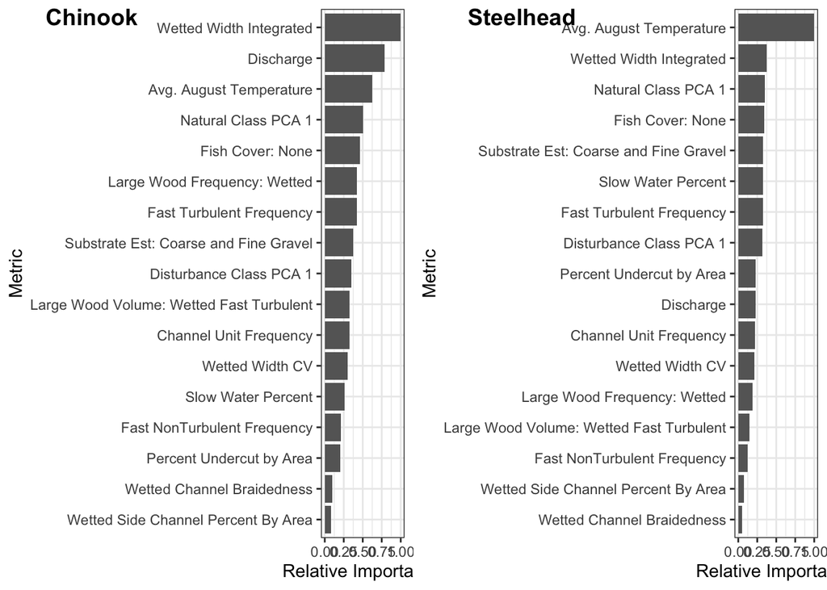

We then created partial dependence plots for each covariate, which show the marginal effect of each covariate on predicted capacities. These plots are made by holding all other metrics fixed at their average value, and allow the one metric to vary across it’s range, while making predictions using the random forest model at many points along that gradient. We used the 90th quantile of the predictions at each point as a proxy for carrying capacity

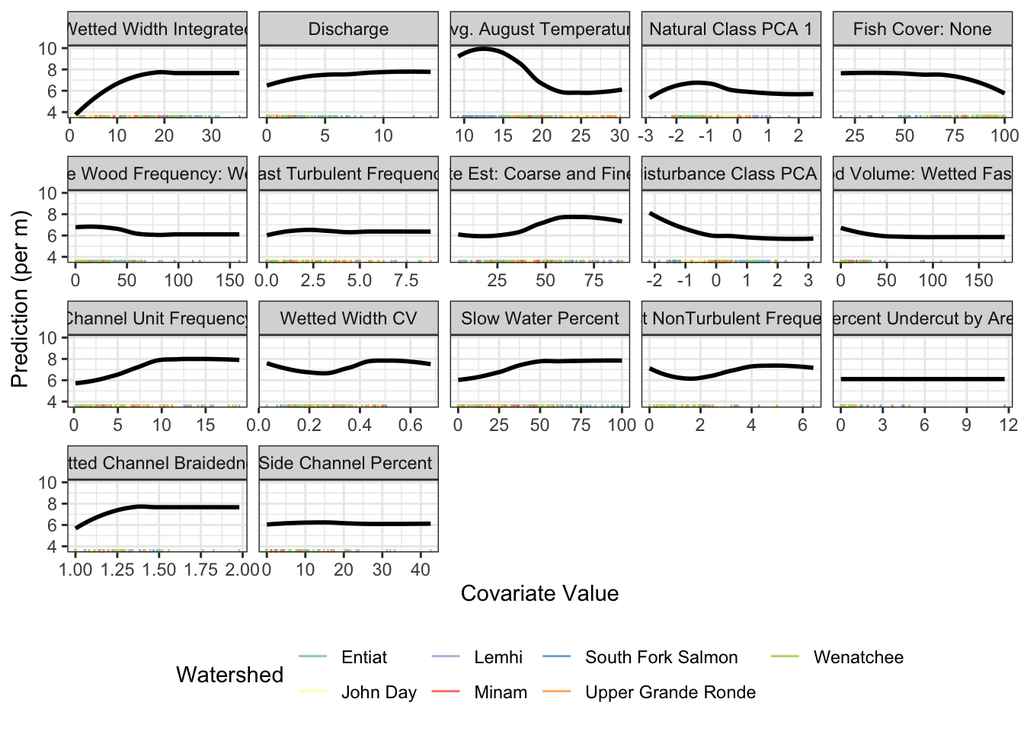

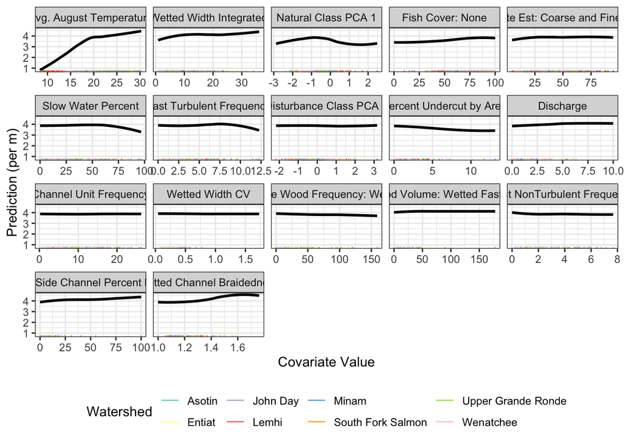

# Predict at Habitat Sites

## Methods

Direct estimates of capacity can be made at all the sites for which we have habitat data with the selected QRF covariates. At each site, the random forest model produces a number (e.g. 1000) of predictions of fish density based on those covariates. As a proxy for carrying capacity, we choose to use the 90th quantile of those predictions (Cade and Noon (2003)).

## Results

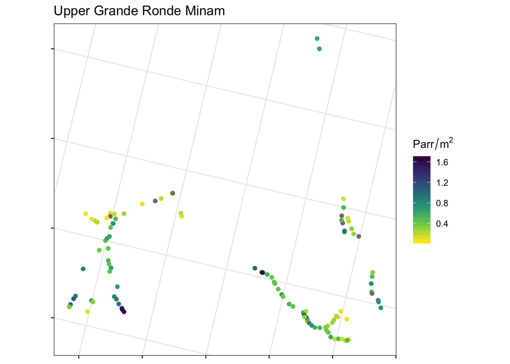

# Extrapolation to Other Sites

To estimate watershed capacities, we used QRF predictions at all the sites where we had habitat data, and used those as the response variable in an extrapolation model. The covariates for this model are globally available attributes (GAAs) which are attached to every master sample point.

[output not shown]

Because most of our habitat data came from CHaMP sites, which were selected through a generalized random tesselation stratified (GRTS) sample design (Stevens and Osen (2003)), we wanted to incorporate the design weights for each CHaMP site with a predicted carrying capacity.

| Watershed | tot_length_km | missing_length | perc_missing |
| --- | --- | --- | --- |
| Entiat | 71.58 | 3.363 | 0.04699 |
| Upper Grande Ronde | 192.6 | 5.267 | 0.02734 |
| John Day | 216.1 | 2.374 | 0.01099 |
| Methow | 301.3 | 0.9166 | 0.003042 |
| Yankee Fork | 119.6 | 0.03067 | 0.0002564 |
| Lemhi | 116.9 | 0 | 0 |
| Minam | 62.77 | 0 | 0 |
| South Fork Salmon | 1.633 | 0 | 0 |
| Tucannon | 85.63 | 0 | 0 |
| Wenatchee | 205.5 | 0 | 0 |

We then selected a subset of the globally available attributes (GAAs) to use as extrapolation covariates. This was based on minimizing the correlations between the covariates. We also acknowlegdged which prediction sites had GAAs outside the range of values for the CHaMP sites.

We use the log of predicted capacity wherever we could make those predictions as the response variable, and this group of selected GAAs as the covariates. We then fit a linear model that incorporated the survey design weights by using the `survey` pacakge ((2014)) in R. We fit two main models, one that included CHaMP watershed as a covariate, and one that did not. The former was used to make predictions within all CHaMP watersheds where we had QRF predictions of carrying capacity. The latter was used at all other master sample points.

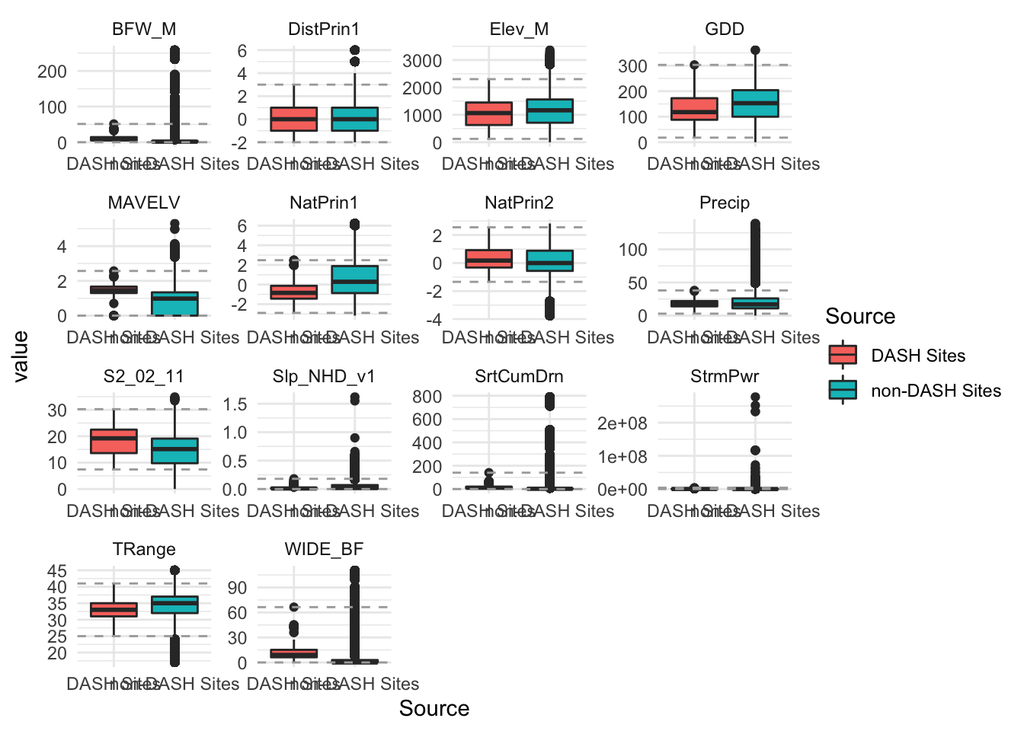

```
#> # A tibble: 16 x 3
#>    x         y               r
#>    <chr>     <chr>       <dbl>
#>  1 BFW_M     SrtCumDrn   0.945
#>  2 Elev_M    NatPrin2    0.847
#>  3 TRange    NatPrin2    0.717
#>  4 GDD       NatPrin1    0.698
#>  5 BFW_M     MAVELV      0.673
#>  6 SrtCumDrn MAVELV      0.660
#>  7 GDD       Elev_M     -0.639
#>  8 Precip    NatPrin1   -0.618
#>  9 Elev_M    S2_02_11   -0.565
#> 10 GDD       Precip     -0.559
#> 11 Precip    S2_02_11   -0.543
#> 12 NatPrin1  DistPrin1   0.542
#> 13 GDD       S2_02_11    0.540
#> 14 Elev_M    DistPrin1  -0.535
#> 15 NatPrin2  DistPrin1  -0.530
#> 16 NatPrin1  Slp_NHD_v1 -0.505
```

# Validation

We can validate Chinook summer parr estimates of capacity with spawner-recruit data from a number of watersheds. Morgan Bond at the Northwest Fisheries Science Center helped compile this data set with help from a variety of agencies and organizations including WDFW, ODFW, IDFG, USFS, BioAnalysts, Biomark, Nez Perce, etc. Most of the parr (recruits) data comes from rotary screw traps (with the exception of the Chiwawa, where snorkel surveys of parr were used to estimate parr directly). Estimates of parr-to-presmolt and parr-to-smolt survival were used to transform estimates of fall and spring emigrants to estimates of equivalent summer parr. Spawner estimates came from either redd counts or direct estimates of spawners.

From this dataset, we fit several spawner-recruit curves to each location, including Beverton-Holt, Ricker and hockey stick. The data at some locations led to some curves not fitting (no model convergence). Each of these spawner-recruit curves also generated an estimate of summer parr carrying capacity, which we can then compare to QRF estimates. We want to emphasize that the data for the spawner-recruit curves and the QRF estimates are completely independent, and therefore provide a good way to validate the QRF estimates of carrying capacity.

```
#> [1] "No stream within polygon"
#> [1] "No stream within polygon"
#> [1] "No stream within polygon"
```

We can estimate a Beverton-Holt spawner-recruit curve with the capacity parameter fixed to the QRF estimate of capacity for that watershed.

We then plotted the data, as well as the fitted curves, including the one which uses QRF estimates of capacity as one of the parameters, on the same plot, to compare the various estimates.

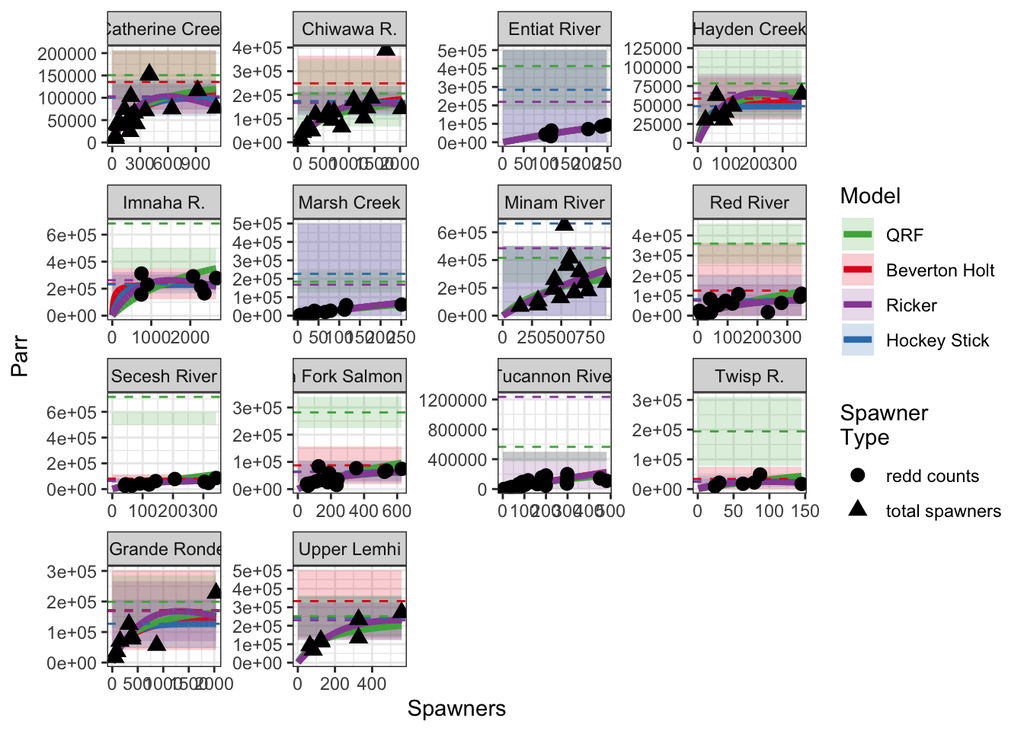

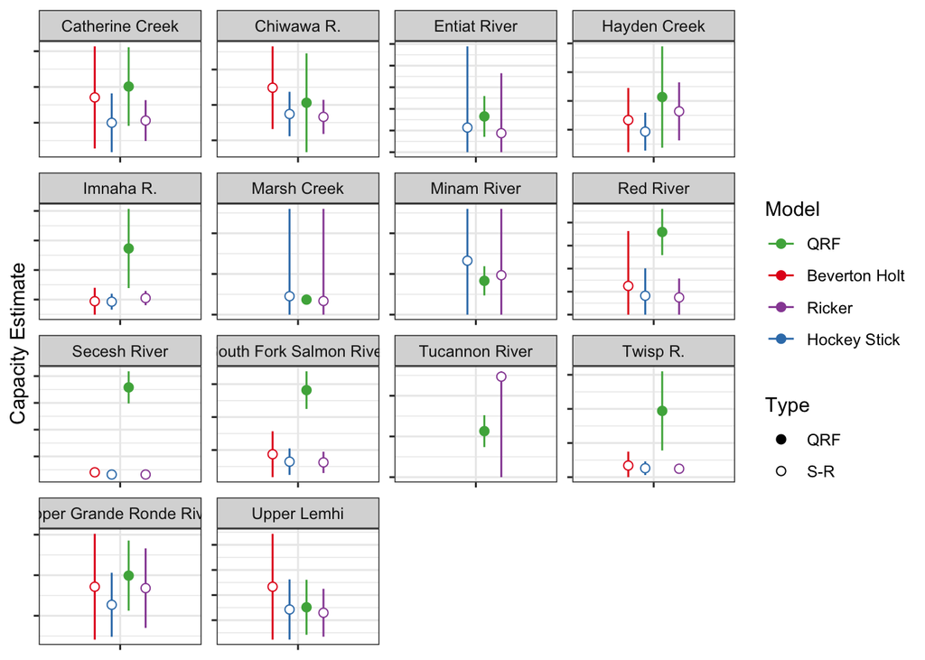

# Watershed Capacity Estimates

We can use the predictions of capacity at all master sample points to estimate carrying capacity at the watershed level. To do so, we join the points to a stream layer, and estimate the average capcity (fish per meter) from all the points on each stream. We then multiply that average by the length of the stream. Finally, we can add the capacities of all the streams within a watershed to determine the overall carrying capacity.

We can also map those capacities on the landscape. For mapping, we have found that displaying the capacity in units of fish per m$^2$ is more intuitive for the viewer to interpret.

## Tables

| StreamName | area | n_pts | tot_length | tot_cap | tot_cap_se | cap_per_m | cap_per_m_se |
| --- | --- | --- | --- | --- | --- | --- | --- |
| Bear Valley Creek | NA | 4 | 2,288 | 3,870 | 3,192 | 1.691 | 1.395 |
| Big Eightmile Creek | NA | 2 | 931.4 | 3,778 | 1,129 | 4.057 | 1.212 |
| Big Springs Creek | NA | 20 | 6,762 | 26,596 | 7,825 | 3.933 | 1.157 |
| Big Timber Creek | NA | 4 | 2,009 | 9,594 | 2,317 | 4.775 | 1.153 |
| Bohannon Creek | NA | 3 | 1,411 | 2,994 | 1,653 | 2.121 | 1.171 |
| Canyon Creek | NA | 9 | 6,240 | 17,094 | 7,300 | 2.739 | 1.17 |
| Hayden Creek | NA | 29 | 19,909 | 79,252 | 23,174 | 3.981 | 1.164 |
| Kenney Creek | NA | 3 | 1,483 | 5,961 | 1,730 | 4.019 | 1.166 |
| Lee Creek | NA | NA | 1,400 | NA | NA | NA | NA |
| Lemhi River | NA | 137 | 99,972 | 385,112 | 115,414 | 3.852 | 1.154 |
| Little Springs Creek | NA | NA | 5,019 | NA | NA | NA | NA |
| Salmon River | NA | NA | 68,528 | NA | NA | NA | NA |
| Wimpey Creek | NA | 4 | 2,761 | 9,126 | 3,242 | 3.305 | 1.174 |
| Total | 3,812 | 258 | 218,716 | 543,377 | 118,343 | 3.78 | 1.161 |
| NA | NA | 43 | NA | NA | NA | 2.217 | 1.338 |

## Maps

```
#> [1] "unzipping..."
```

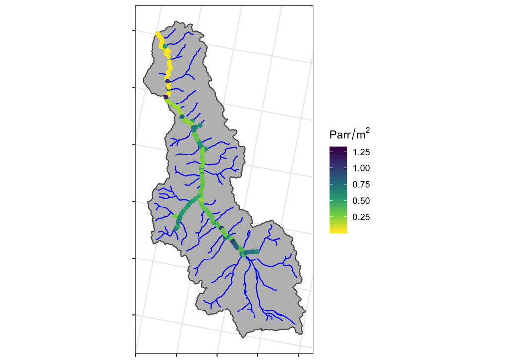

# References

Cade, B. S., and B. R. Noon. 2003. A gentle introduction to quantile regression for ecologists. Frontiers in Ecology and the Environment 1:412–420.

Carle, F. L., and M. R. Strub. 1978. A new method for estimating population size from removal data. Biometrics:621–630.

Chapman, D. G. 1951. Some properties of the hypergeometric distribution with applications to zoological sample censuses. University of California Press.

Hedger, R. D., E. De Eyto, M. Dillane, O. H. Diserud, K. Hindar, P. McGinnity, R. Poole, and G. Rogan. 2013. Improving abundance estimates from electrofishing removal sampling. Fisheries Research 137:104–115.

Lumley, T. 2014. Survey: Analysis of complex survey samples. R package version 3.30.

Meinshausen, N. 2012. QuantregForest: Quantile regression forests.

Meinshausen, N. 2006. Quantile regression forests. Journal of Machine Learning Research 7:983–999.

R Core Team. 2015. R: A language and environment for statistical computing. R Foundation for Statistical Computing, Vienna, Austria.

Reshef, D. N., Y. A. Reshef, H. K. Finucane, S. R. Grossman, G. McVean, P. J. Turnbaugh, E. S. Lander, M. Mitzenmacher, and P. C. Sabeti. 2011. Detecting novel associations in large data sets. Science 334:1518–1524.

Robson, D., and H. Regier. 1964. Sample size in petersen mark–recapture experiments. Transactions of the American Fisheries Society 93:215–226.

Seber, G. A. F. 2002. The estimation of animal abundance and related parameters. Blackburn Press Caldwell, New Jersey.

Stevens, D., and A. Osen. 2003. Variance estimation for spatially balanced samples of environmental resources. Environmetrics 14:593–610.

[^1]: Biomark Inc.